# GMO

```python
%load_ext autoreload
%autoreload 2
%matplotlib inline
```

```
The autoreload extension is already loaded. To reload it, use:
  %reload_ext autoreload
```

```python
import matplotlib.pyplot as plt
from pylab import rcParams
rcParams['figure.figsize'] = 16, 8

import re
import numpy as np
import pandas as pd
pd.set_option('display.max_columns', None)
```

```python
import src.helpers as hp
```

```python
# Todo: Add credentials tester....
dbconnect = hp.DBConnector()
```

```
Please enter your ssh password :

········
```

## Tweets labeled as GMO (concept)

```python
query = """
select doc.*, concept.id concept_id, concept.name, concept.we_vector
from public.document doc

join public.document_concept dc
on dc.document_id = doc.id

join public.concept concept
on concept.id = dc.concept_id

where concept.name like 'GMO'

limit 100
"""

data = dbconnect.query_database('data20171', query)

# nb:
# use dbconnect.query_4db(query) to gather result from all databases
```

```
>>> server connected (user is: furrer)
>>> database connected
```

### Samples of tweet on GMO

#### Notes

From the reading of those samples, we can already think about a few tasks/challenges

- Remove all usernames in body (@*username*)

  > simple regex
- Remaining Hashtags in body (#*hashtag*)

  > To be deleted? Corresponds to hashtags table ?  
  > Beware of hashtags inserted in sentences
- Attached links to be explored
  1. Websites blacklist ? (Hoaxers) / Compute a reliability score ?
     - Unreachable (404)
  2. Content : Author? NER? Time delta btw tweet and article?
  3. Overall reliability score ?
- Uncomplete tweets' texts

  > Link to complete tweet is usually in the body
- Tweets out of context (no answers/responses)

```python
suspicion_dict = {
    'person' : [
        'judy carman',
        'Gilles-Eric Séralini'
    ],
    'words' : [
        'bad words/adjectives/...'
        'frankenfood',
        'zika',

    ]
}
```

```python
# Add column with printing-friendly format
data['printable'] = ''
data['printable'] = '[ ' + data.sentiment.astype(str) + ' ]\n' + data.body + '\n'
```

```python
[print(e) for e in data.printer];
```

```
[ -0.2144 ]
@RealJamesWoods this I have a problem with. Round up and GMOs. Kicked out of every country but the US. https://t.co/7ttxsmwP9K

[ 0.0 ]
Whatever anyone says, most #GMO is harmful to our #health!
https://t.co/W7FBthQEb4
#CleanEating #Healthy #Weightloss #YouMatter #Fitness https://t.co/8KjpqkEfoc

[ 0.0 ]
Attorneys Allege EPA Colluded with Monsanto #GMOs #GMO https://t.co/ksAd4zPrz5 /fd https://t.co/Y3HjQL3PF6

[ 0.0 ]
GMO Click’s Monthly FX Trading Volumes Decline in April 2017, story via FinanceMagnates https://t.co/w3LHpmDfuJ

[ 0.126 ]
Now we have GMO apples to contend with! Yet another reason why buying organic is the way to go. https://t.co/Rvnm9z7si4

[ 0.1585 ]
See how chipotletweets gives its ingredients the royal treatment. mow say natural ? Shit ingr NOT GMO FREE OR CERT ORGANIC JUST CLEANER NICE

[ 0.4019 ]
Physicians for Social Responsibility Support Labeling of GMO Foods | PSR https://t.co/YE6VuuY4Ta https://t.co/mhN1jfDTye

[ 0.3182 ]
The truth about GMOs https://t.co/LczPLBvN4r

[ 0.0772 ]
@piaintx @DebolDog @mercola @RobSchneider So is your definition of "GMO" different than this? https://t.co/PzOX7ARBLZ I want to understand what exactly concerns you.

[ 0.0 ]
Choosing Technology to Enhance Sustainability #GMO - @GlobalFarmerNet https://t.co/UJtU05Msxv

[ 0.0 ]
Obama Signs Industry-Backed GMO Label Bill Into Law https://t.co/IXxzGvZccX

[ 0.0 ]
Boulder County, Colorado to phase out GMO crops and neonicotinoid insecticides via @jfryarTC #Neonicotinoid #3 https://t.co/ObBjYntWmv

[ 0.0 ]
Do you read the enormous, shit-storm chemical lists of stuff they WILL tell us are in there? Add GMOs, but won't, s… https://t.co/t75TpukyWV
```

[output cut: 272 more lines]

```

[ 0.2023 ]
Focus on agribiotech: GMO https://t.co/f2tjyTjEak - top stories by @AmyPage78, @FightingPandaCo, @davespadafora

[ 0.6124 ]
I watched the episode about GMOs, and while I've always agreed that genetically modified foods were a good thing, the piece of the &gt;&gt;

[ 0.4926 ]
The latest GMO Exposᶒ! https://t.co/xYH3rR7Lv3 Thanks to @ThamFarm_IVF @VincentKopp @eatsustainable #gmo #gmos

[ 0.0 ]
New study discovers major differences between GMO and non-GMO corn https://t.co/zPv0udmrBx

[ -0.296 ]
While organic foods are required to be GMO-free, there is no such requirement for "natural" foods.
```

#### Specific examples

```python
id_ = data.id.sample(1).values[0]
```

#### 1. Judy Carman study

```python
id_ = '0457d690-59a0-11e7-b7d0-0242ac110004'
print(data[data.id == id_].printable.values[0])

concepts, topics, hashtags, issues = dbconnect.get_context(id_=id_)
topics
```

```
[ 0.0 ]
Whatever anyone says, most #GMO is harmful to our #health!
https://t.co/W7FBthQEb4
#CleanEating #Healthy #Weightloss #YouMatter #Fitness https://t.co/8KjpqkEfoc
```

|  | topic_rank | topic_label |
| --- | --- | --- |
| 0 | 1 | GMO, Bioengineering |

```python
issues
```

|  | document_id | issue_id | issue_rank | issue_name |
| --- | --- | --- | --- | --- |
| 0 | 0457d690-59a0-11e7-b7d0-0242ac110004 | aaaaaaaa-aaaa-11e5-1216-42010af074fc | 1 | green fluorescent protein cause meat cancer |

#### 2. ??

```python
id_ = '54204e98-d6db-11e6-b3f5-0242ac110007'
print(data[data.id == id_].printable.values[0])

concepts, topics, hashtags, issues = dbconnect.get_context(id_=id_)
topics
```

```
[ 0.6496 ]
https://t.co/AFw26tJ7o4

HELP LABEL #GMO Ez2C ON PACKAGE!!!
#NoQR

@Stonyfield
@WholeFoods
@OrganicValley
@Gary_Hirshberg
@JustLabelIt
@EWG
```

|  | topic_rank | topic_label |
| --- | --- | --- |
| 0 | 1 | Fresh Food, Real Food, Healthy Food |
| 1 | 2 | GMO, Bioengineering |

#### 3. Russel Blaylock

```python
id_ = '02b95d8a-4119-11e7-bd54-0242ac110003'
print(data[data.id == id_].printable.values[0])

concepts, topics, hashtags, issues = dbconnect.get_context(id_=id_)
topics
```

```
[ -0.4767 ]
I added a video to a @YouTube playlist https://t.co/JZBqYOaADP GMO Food — It's Worse Than We Thought - Dr. Russell Blaylock
```

|  | topic_rank | topic_label |
| --- | --- | --- |
| 0 | 1 | GMO, Bioengineering |

Quote about Russel Blaylock $\rightarrow$`Schwarcz characterized these positions as "conspiracy theories".`

Source: [Wikipedia page](https://en.wikipedia.org/wiki/Russell_Blaylock) : Section 'Views on politics'

```python
print(data.printer.sample(1).values[0])
```

```
[ -0.4717 ]
@letmeexplainit All the more reason to not let Monsanto win. We should get a compilation of interviews of what Farmers think of GMOs &amp; Monsanto.
```

```python
print(data.printer.sample(1).values[0])
```

```
[ 0.2023 ]
Focus on agribiotech: GMO https://t.co/f2tjyTjEak - top stories by @BitcoinArabia, @CryptocoinWorld, @zosegal
```

## 2. Time & Volume exploration

Let's see the distribution in time of the volumne of tweets on GMO

1. Total amount
2. Mean & Var of sentiment over time

```python
import plotly.plotly as py
import plotly.graph_objs as go

from plotly.offline import iplot
import cufflinks
cufflinks.go_offline()
```

**/!\ Long running cell !** Be aware that running the next cell will take a considerable amount of time!

```python
%%time
query = """
select count(*)
from public.document doc

join public.document_concept dc
on dc.document_id = doc.id

join public.concept concept
on concept.id = dc.concept_id

where concept.name like 'GMO'
"""

df = dbconnect.query_4db(query)
```

```
>>> server connected (user is: furrer)
>>> Query database data20171
>>> Query database data20172
>>> Query database data20181
>>> Query database data20182
```

```python
df.index = ['db1', 'db2', 'db3', 'db4']
df.columns = ['nb_tweets']
print("Number of tweets about GMO:")
df.head()
```

```
Number of tweets about GMO:
```

|  | nb_tweets |
| --- | --- |
| db1 | 229583 |
| db2 | 169274 |
| db3 | 219905 |
| db4 | 152713 |

```python
tot_n_gmo_tweets = np.array([229583, 169274, 219905, 152713]).sum()
```

(hardwritten for length-of-query purpose...)

|  | # of tweets |
| --- | --- |
| **1st semester of 2017** (db1) | 229'583 |
| **2nd semester of 2017** (db2) | 169'274 |
| **1st semester of 2018** (db3) | 219'905 |
| **2nd semester of 2018** (db4) | 152'713 |
| **Total :** | 771'475 |

Same query but sub-sampled for computation efficiency reasons...

```python
%%time
query = """
select doc.*, concept.id concept_id, concept.name, concept.we_vector

from public.document doc
join public.document_concept dc
on dc.document_id = doc.id
join public.concept concept
on concept.id = dc.concept_id

where concept.name like 'GMO'
--limit 10000
limit 5000
"""

data = dbconnect.query_4db(query)

# Compute publishing dates without hours for better visualizations
data['publishing_day'] = data.publishing_date.dt.round('D')
data['publishing_month_year'] =data['publishing_date'].dt.to_period('M')

print("{} Tweets extracted".format(data.shape[0]))
```

```
>>> server connected (user is: furrer)
>>> Query database data20171
>>> Query database data20172
>>> Query database data20181
>>> Query database data20182
20000 Tweets extracted
Wall time: 33.5 s
```

```python
data.groupby('publishing_month_year')['publishing_month_year'].count()\
    .iplot(kind='bar',
           title='Monthly volume of tweets about GMOs (Sample of {}%)'.format(round(data.shape[0]/tot_n_gmo_tweets, 3)))
```

[interactive chart not shown]

```python
data.groupby('publishing_day')['publishing_day'].count()\
    .iplot(kind='bar',
          title='Daily volume of tweets about GMOs (Sample of {}%)'.format(round(data.shape[0]/tot_n_gmo_tweets, 3)))
```

[interactive chart not shown]

#### Notes:

- Spike in Feb 18

### 2.1 Frequent topics / words

```python
from sklearn.feature_extraction.text import TfidfVectorizer, TfidfTransformer
from sklearn.feature_extraction.text import CountVectorizer
```

```python
data['publishing_month_year'].dt.year
```

```
<pandas.core.indexes.accessors.PeriodProperties object at 0x000002082F1A0128>
```

```python
year_s = data['publishing_month_year'].dt.year==2018
month_s = data['publishing_month_year'].dt.month==2
test = data.loc[year_s & month_s].copy()
```

```python
test = data.sample(5).copy()
```

```python
test['body'] = ['I like GMOs',
               'GMOs will kill you',
               'New GMO, new dangerous threat for our world...',
               'is this a new dangerous gmo from evil Monsanto ?',
               'If this is not a proof that #GMOs are dangerous for your health']
```

```python
test['printable'] = ''
test['printable'] = '[ ' + test.sentiment.astype(str) + ' ]\n' + test.body + '\n'

# Lambda function to remove urls :
rurl = lambda e : re.sub(r"http\S+", "", e)
```

```python
[print(e) for e in test.printable[:5]];
```

[output not shown]

```python
test['body'] = test['body'].apply(rurl)

vectorizer = CountVectorizer(stop_words='english')
X = vectorizer.fit(test.body.values)

#print(vectorizer.get_feature_names())

bag_of_words = vectorizer.transform(test.body.values)
sum_words = bag_of_words.sum(axis=0)

words_freq = [(word, sum_words[0, idx]) for word, idx in vectorizer.vocabulary_.items()]
words_freq = sorted(words_freq, key = lambda x: x[1], reverse=True)
```

```python
words_freq[:10]
```

[output not shown]

### Doest TF-IDF brings something interesting?

```python
tfidf_vect = TfidfVectorizer(stop_words='english', ngram_range=(1,2))
```

```python
from collections import defaultdict

X = tfidf_vect.fit_transform(test.body.values)
features_by_gram = defaultdict(list)

for f, w in zip(tfidf_vect.get_feature_names(), tfidf_vect.idf_):
    features_by_gram[len(f.split(' '))].append((f, w))

top_n = 10
for gram, features in features_by_gram.items():
    top_features = sorted(features, key=lambda x: x[1], reverse=True)[:top_n]
    top_features = [f[0] for f in top_features]
    print('{}-gram top:'.format(gram), top_features)
```

[output not shown]

### Same TF/TF-IDF - WITH Stemming

```python
from nltk.stem.snowball import SnowballStemmer
stemmer = SnowballStemmer("english")
```

```python
test['body'] = test['body'].apply(rurl)
test['stemmed'] = test.body.map(lambda x: ' '.join([stemmer.stem(y) for y in x.split(' ')]))
test.stemmed.head().values
```

[output not shown]

```python
corpus = test.stemmed
```

```python
counter_vect = CountVectorizer(stop_words='english', min_df=1, max_df=1., ngram_range=(1,2))
counter_vect.fit(corpus);
```

```python
# Compute document-term Matrix
dt_matric = counter_vect.transform(corpus)
print('Matrix shape (sparse):', dt_matric.shape)
print('Nonzero elem:', dt_matric.nnz)
print('Sparsity: %.2f%%' % (100.0 * dt_matric.nnz / (dt_matric.shape[0] * dt_matric.shape[1])))
```

[output not shown]

```python
occ = np.asarray(dt_matric.sum(axis=0)).ravel().tolist()
counts_df = pd.DataFrame({'term': counter_vect.get_feature_names(), 'occurrences': occ})
counts_df.sort_values(by='occurrences', ascending=False).head(10)
```

|  | occurrences | term |
| --- | --- | --- |
| 4817 | 1564 | gmo |
| 4425 | 1198 | free |
| 8369 | 1155 | non gmo |
| 8368 | 1155 | non |
| 4764 | 1145 | gluten |
| 5559 | 1127 | healthi |
| 2864 | 1121 | dairi |
| 2867 | 1118 | dairi free |
| 6814 | 1117 | kosher |
| 4442 | 1117 | free kosher |

```python
tfid_vect = TfidfVectorizer(min_df=.0025, max_df=.5, stop_words='english', ngram_range=(1,2))
tvec_weights = tfid_vect.fit_transform(corpus.dropna())
weights = np.asarray(tvec_weights.mean(axis=0)).ravel()#.tolist()
weights_df = pd.DataFrame({'term': tfid_vect.get_feature_names(), 'weight': weights})
weights_df.sort_values(by='weight', ascending=False).head(10)
```

|  | term | weight |
| --- | --- | --- |
| 332 | snack everyon | 0.138592 |
| 101 | everyon non | 0.138592 |
| 100 | everyon | 0.138556 |
| 27 | bar ideal | 0.128551 |
| 189 | ideal | 0.128551 |
| 190 | ideal snack | 0.128551 |
| 28 | bar perfect | 0.123383 |
| 268 | perfect snack | 0.123383 |
| 267 | perfect | 0.123372 |
| 331 | snack everybodi | 0.111508 |

### Word cloud

```python
#from PIL import Image
from wordcloud import WordCloud, STOPWORDS, ImageColorGenerator
```

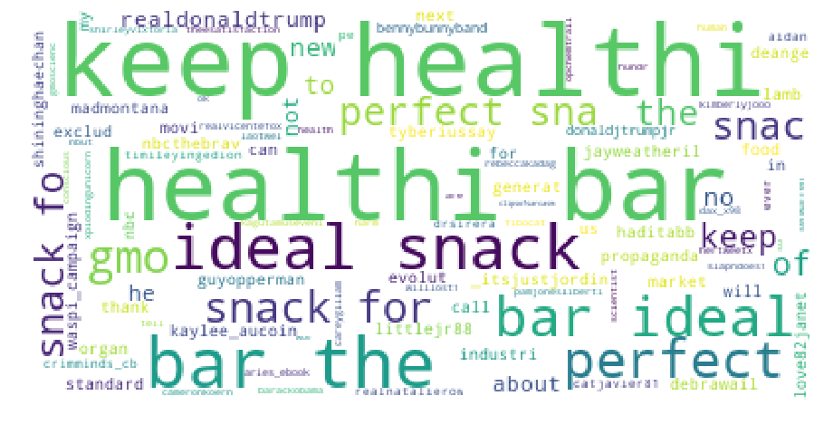

```python
wordcloud = WordCloud(
                          background_color='white',
                          stopwords='english',
                          max_words=100,
                          max_font_size=50,
                          random_state=42
                         ).generate(str(corpus))
#plt.figure(figsize=(10, 6))
plt.imshow(wordcloud)
plt.axis('off');
#fig.savefig("word1.png", dpi=900)
```

## Users exploratory analysis

Let's explore now what kind of users we have.

For instance :

1. People tweeting about GMO also tweet about...
2. What's the ratio of tweets between GMO & other topics
3. Users tweeting only about one topic?